# Контрольная Капуза

Июль, 12, 2018

```r
library(rio)
library(tidyverse)
library(dplyr)
library(ggalluvial)
library(skimr)
library(corrplot)
library(ggpubr)
library(broom)
library(GGally)
library(lmtest)
library(cluster)
library(factoextra)
library(dendextend)
library(sjPlot)
library(caret)
library(FFTrees)
library(margins)
library(rpart.plot)
library(plotROC)
```

Для анализа используется база данных лонгитюдного иследования Института образования НИУ ВШЭ “Траектории в образовании и профессии”.

```r
data <- import('finlallw4R.dta')
glimpse(data)
```

```
## Observations: 4,894
## Variables: 35
## $ idstud       <dbl> 3010101, 3010102, 3010103, 3010104, 3010105, 3010...
## $ np2_q1       <dbl> 2, NA, 2, 1, 4, 2, 4, 1, 4, NA, 2, 1, 2, 4, 3, 2,...
## $ np2_q45      <dbl> 8, NA, 2, 1, 5, 6, NA, NA, 5, NA, 2, 1, 2, 5, 3, ...
## $ np3_q1       <dbl> 3, NA, 3, 1, 4, 3, 4, 1, 4, NA, 3, 2, 3, 4, 4, 3,...
## $ np3          <dbl> 3, 1, 3, 3, 3, 3, 3, 3, 3, 1, 3, 3, 3, 3, 3, 3, 3...
## $ np4_q7       <dbl> NA, NA, NA, NA, NA, NA, NA, NA, NA, NA, NA, NA, 6...
## $ np4_q8       <dbl> NA, NA, NA, NA, NA, NA, NA, NA, NA, NA, NA, NA, 5...
## $ np4_q15      <dbl> NA, NA, NA, 1, 2, NA, NA, 1, NA, NA, NA, NA, 2, 2...
## $ np4_q49      <dbl> NA, NA, NA, NA, 3, NA, NA, NA, NA, NA, NA, NA, 1,...
## $ np4_q50      <dbl> NA, NA, NA, NA, NA, NA, NA, NA, NA, NA, NA, NA, 1...
## $ np4_q50_vuz  <chr> "", "", "", " ", " ", "", "", " ", "", "", "", ""...
## $ np4_q50_spec <chr> "", "", "", " ", " ", "", "", " ", "", "", "", ""...
## $ np4_q61      <dbl> NA, NA, NA, 1, 1, NA, NA, 3, NA, NA, NA, NA, 1, 1...
```

[output cut: 22 more lines]

math_lev3 - уровень математической грамотности респондента по тесту PISA-2012 (низкий/средний/высокий) np2study - где респондент обучается в 2013 г. после 9 класса (нигде/в школе/в СПО) np2wish - какой максимальный уровень образования респондент хочет получить (опрос в 2013 г.) (школа/СПО/высшее/2 высших или кандидат наук) np4_q7 - балл ЕГЭ по математике (только для тех, кто закончил 11 классов) wherenp5 - где респондент обучается в 2015 г. (нигде и не работает/нигде и работает/СПО/высшее образование) np5_q79 - личный доход в 2015 г. np5_q55 - ожидаемая зарплата после окончания ВУЗа (только для респондентов, обучающихся в ВУЗе) np5plan - планирует ли респондент продолжать обучение (2015 г.) (нет/да)

Первые пять должны быть факторнымы, ожидаемая зарплата - остаться в формате dbl.

```r
data_fct <- mutate(data, math_lev3 = factor(math_lev3), np2study = factor(np2study), np2wish  = factor(np2wish), wherenp5 = factor(wherenp5), np5_q79 = factor(np5_q79), np5plans = factor (np5plans) )

data_fct <- mutate(data_fct, np5_q79 = fct_collapse(np5_q79, "7" = c('7', '8', '9', '10')))
```

Кроме того, в дальнейшем нам понадобятся лейблы значения для построения графиков.

```r
levels(data_fct$math_lev3) <- c("Низкий", "Средний", "Высокий")
levels(data_fct$np2study) <- c("Не учится", "Школа", "СПО")
levels(data_fct$np2wish) <- c("Школа", "СПО", "ВО", "2 ВО или степень")
levels(data_fct$wherenp5) <- c("Не учится и не работает", "Не учится и работает", "СПО", "ВО")
levels(data_fct$np5_q79) <- c("<5 тыс.", "5-10 тыс.", "10-15 тыс.", "15-20 тыс.", "20-25 тыс.", "25-30 тыс.", ">30 тыс.")
```

# 1 Описательная статистика

Построим гистограммы для переменных, показывающих место обучения респондентов в волне 2 и в волне 5

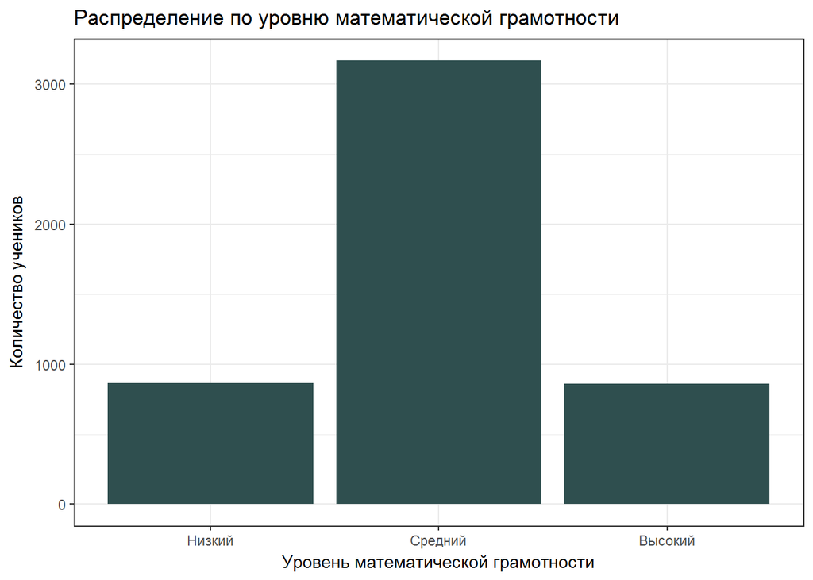

```r
ggplot(data = data_fct) +
  geom_histogram(aes(x = math_lev3), fill = "#2F4F4F",  stat="count") +
  labs(x = 'Уровень математической грамотности', y = 'Количество учеников' , title = 'Распределение по уровню математической грамотности') +
  theme_bw()
```

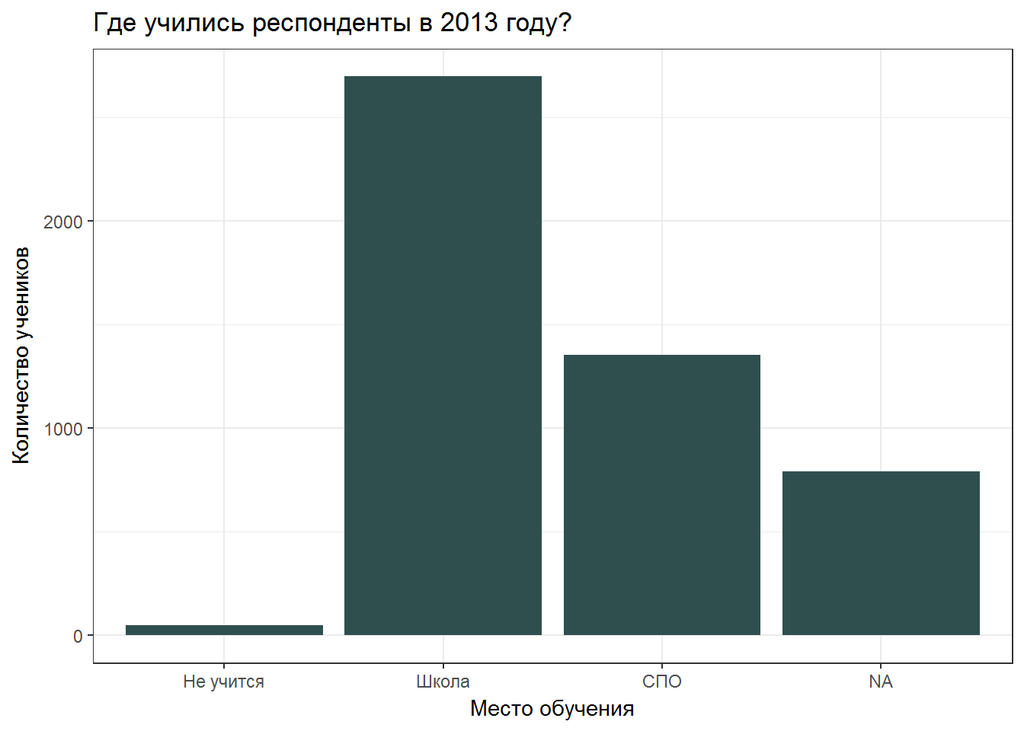

```r
ggplot(data = data_fct) +
  geom_histogram(aes(x = np2study), fill = "#2F4F4F", stat="count") +
  labs(x = 'Место обучения', y  = 'Количество учеников' , title = 'Где учились респонденты в 2013 году?') +
  theme_bw()
```

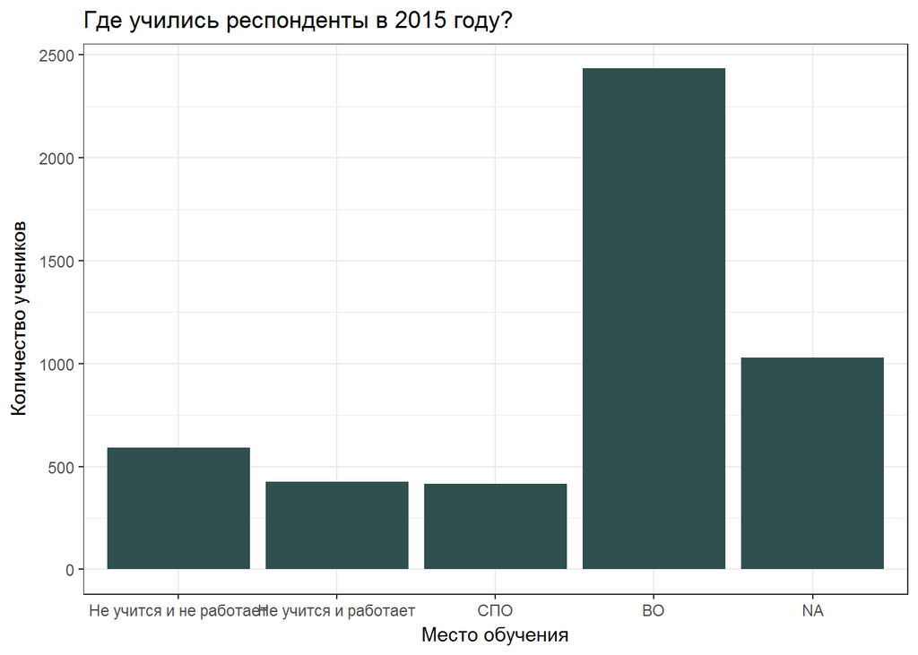

```r
ggplot(data = data_fct) +
  geom_histogram(aes(x = wherenp5), fill = "#2F4F4F", stat="count") +
  labs(x = 'Место обучения', y = 'Количество учеников' , title = 'Где учились респонденты в 2015 году?') +
  theme_bw()
```

Построим потоковый график для ожидаемого уровня образования в волне 2 и текущего метса обучения в волне 5 в зависимости от уровня грамотности респондента.

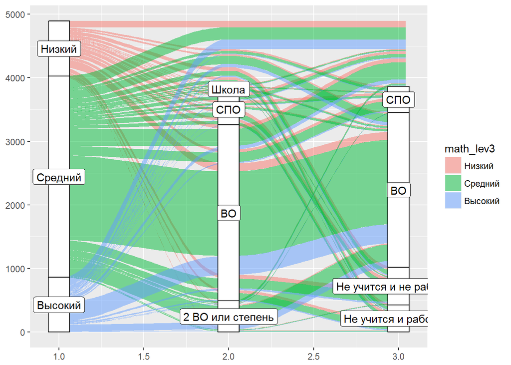

```r
freq_table <- group_by(data_fct, math_lev3, np2wish, wherenp5) %>% summarise(freq = n())

ggplot(data = freq_table,
       aes(weight = freq, axis1 = math_lev3, axis2 = np2wish, axis3 = wherenp5)) +
  geom_alluvium(aes(fill = math_lev3), width = 1/12) +
  geom_stratum(width = 1/8) +
  geom_label(stat = "stratum", label.strata = TRUE)
```

Так как текущий доход измерен на порядковой шкале, вместо диаграммы рассеяния построим боксплоты и графики-виолончели для ожидаемого дохода. Так как некоторые респонденты давали нереалистичные прогнозы, мы сделали график только для тех, кто отметил ожидаемый доход ниже 200 т.р.

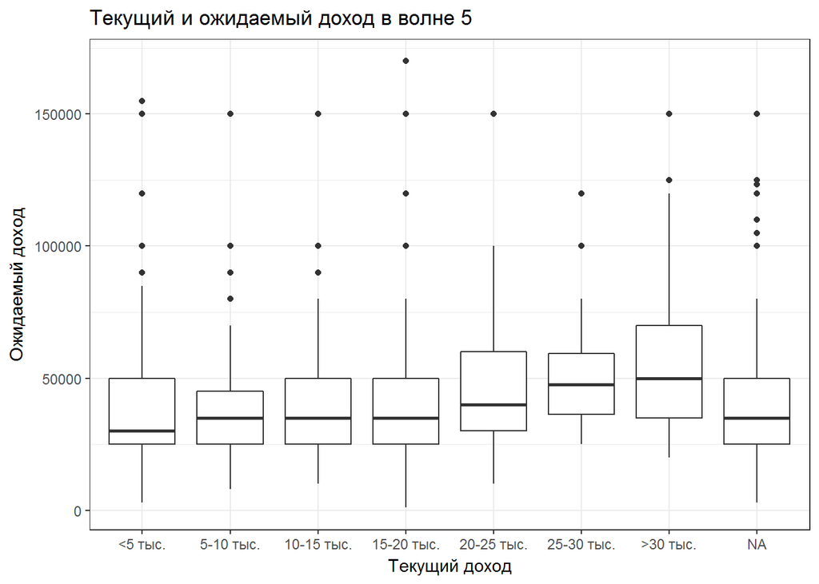

```r
data_salary <- subset(data_fct, np5_q55 < 200000)

ggplot(data = data_salary) +
  geom_boxplot(aes(x = np5_q79, y = np5_q55)) +
  labs(x = 'Текущий доход', y = 'Ожидаемый доход', title = 'Текущий и ожидаемый доход в волне 5') +
  theme_bw()
```

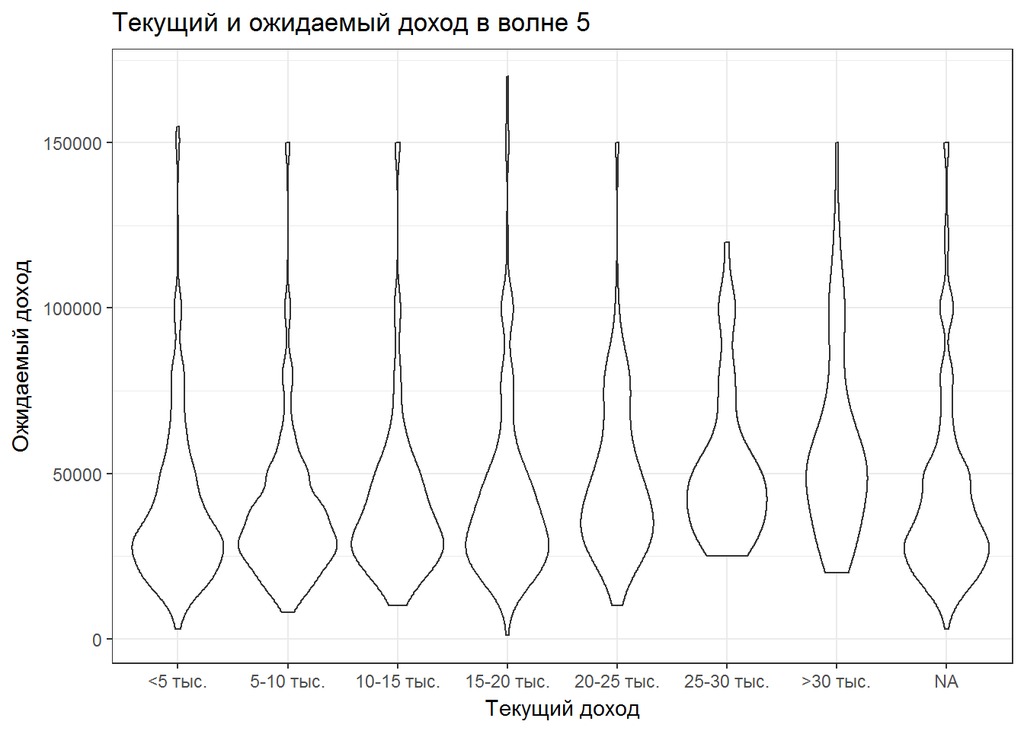

```r
ggplot(data = data_salary) +
  geom_violin(aes(x = np5_q79, y = np5_q55)) +
  labs(x = 'Текущий доход', y = 'Ожидаемый доход', title = 'Текущий и ожидаемый доход в волне 5') +
  theme_bw()
```

В целом, чем выше текущий личный доход респондента, тем больший доход он ожидает после окончания ВУЗа. И в данном случае боксплоты явно привлекательнее)

Посмотрим на корреляцию между баллом ЕГЭ по математике и ожидаемым доходом:

```r
wage_cor <- cor(data_salary$np5_q55, data_salary$np4_q7, use = "complete.obs" )
wage_cor
```

```
## [1] 0.1342932
```

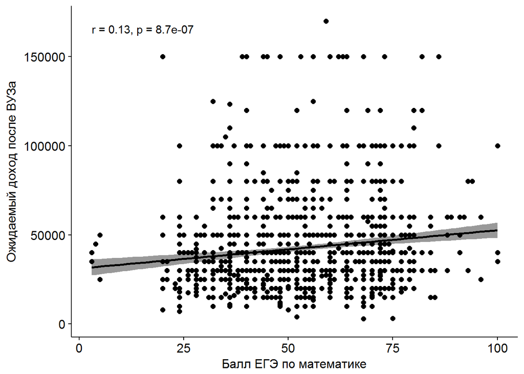

```r
ggscatter(data_salary, x = "np4_q7", y = "np5_q55",
          add = "reg.line", conf.int = TRUE,
          cor.coef = TRUE, cor.method = "pearson",
          xlab = "Балл ЕГЭ по математике", ylab = "Ожидаемый доход после ВУЗа")
```

Корреляция крайне слабая, но значимая.

# 2 Кластеризация

Попробуем кластеризовать респондентов по набору их ожиданий в отношении образования, получаемого образования и математической грамотности. Так как мы не имеем ни млейшего понятия, как могут группироваться данные, прибегнем к иерархическому анализу.

```r
data_clust2 <- subset(data, select = c(idstud, math_lev3, np2study, np2wish) , np2study != "NA")
data_clust <- subset(data_clust2, np2wish != "NA")

clust_data <- dist(data_clust,  method = 'euclidian')

#hier <- hclust(data_clust, method = "ward.D2", members = NULL)
#fviz_dend(hier)
```

Note: я очень долго билась с тем, чтобы засунуть факторные переменные в кластерный анализ, как это делается в стате. Но R упорно писал “NAs introduced by coercion”. Если я правильно понимаю, это невозможно, и мы теперь должны гадать, что за цифры там на деревьях.

Кроме того, hclust получается через раз - и не видно никакой системы в том, когда он получается, а когда пишет Error in if (is.na(n) || n > 65536L) stop(“size cannot be NA nor exceed 65536”) : missing value where TRUE/FALSE needed

Кажется (в тот момент, когда получается hclust), что оптимальное число кластеров 5. Так и сделаем.

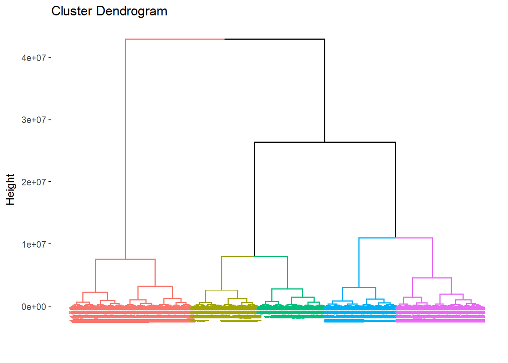

```r
clust_n <- hcut(data_clust, k = 5, hc_metric = 'euclidean', hc_method = 'ward.D2')

fviz_dend(clust_n,  cex = 0.5,  color_labels_by_k = TRUE)
```

Изобразим полученные кластеры в осях главных компонент

```r
#data_pca <- prcomp(data_clust, na.rm = TRUE)
#fviz_pca_ind(data_pca, repel = TRUE)
```

Опять что-то про миссинги (Error in svd(x, nu = 0, nv = k) : infinite or missing values in ‘x’)

# 3 Линейная регрессия

Построи регрессию с ожидаемой зарплатой в качестве зависимой переменной и уровнем грамотности по математике, баллом ЕГЭ по математике, ожиданиями от уровня образования и текущего места обучения в волне 2 в качестве независимых.

```r
reg_salary <- lm(data = data_salary, np5_q55 ~ math_lev3 + np4_q7 + I(np2study == "Не учится") + I(np2study == "Школа") +  I(np2wish == "Школа") + I(np2wish == "СПО") + I(np2wish == "2 ВО или степень"), na.action = na.omit)
summary(reg_salary)
```

```
##
## Call:
## lm(formula = np5_q55 ~ math_lev3 + np4_q7 + I(np2study == "Не учится") +
##     I(np2study == "Школа") + I(np2wish == "Школа") + I(np2wish ==
##     "СПО") + I(np2wish == "2 ВО или степень"), data = data_salary,
##     na.action = na.omit)
##
## Residuals:
##    Min     1Q Median     3Q    Max
## -40867 -15900  -7034   8318 128631
##
## Coefficients:
##                                      Estimate Std. Error t value Pr(>|t|)
## (Intercept)                          27565.90    6300.04   4.376 1.31e-05
## math_lev3Средний                      -238.24    3165.75  -0.075 0.940024
## math_lev3Высокий                      5895.91    3625.88   1.626 0.104190
## np4_q7                                 156.41      47.27   3.309 0.000963
## I(np2study == "Не учится")TRUE       88913.33   25502.28   3.486 0.000507
## I(np2study == "Школа")TRUE            4813.47    5522.74   0.872 0.383610
## I(np2wish == "Школа")TRUE             3494.26    4800.53   0.728 0.466818
## I(np2wish == "СПО")TRUE              -5226.14    6545.29  -0.798 0.424757
## I(np2wish == "2 ВО или степень")TRUE  3755.75    1856.38   2.023 0.043271
##
## (Intercept)                          ***
## math_lev3Средний
## math_lev3Высокий
## np4_q7                               ***
## I(np2study == "Не учится")TRUE       ***
## I(np2study == "Школа")TRUE
## I(np2wish == "Школа")TRUE
## I(np2wish == "СПО")TRUE
## I(np2wish == "2 ВО или степень")TRUE *
## ---
## Signif. codes:  0 '***' 0.001 '**' 0.01 '*' 0.05 '.' 0.1 ' ' 1
##
## Residual standard error: 24900 on 1240 degrees of freedom
##   (397 observations deleted due to missingness)
## Multiple R-squared:  0.04114,    Adjusted R-squared:  0.03495
## F-statistic:  6.65 on 8 and 1240 DF,  p-value: 1.529e-08
```

```r
coefci(reg_salary)
```

```
##                                             2.5 %      97.5 %
## (Intercept)                           15205.97257  39925.8231
## math_lev3Средний                      -6449.04753   5972.5707
## math_lev3Высокий                      -1217.62656  13009.4542
## np4_q7                                   63.67402    249.1479
## I(np2study == "Не учится")TRUE        38880.94911 138945.7046
## I(np2study == "Школа")TRUE            -6021.46985  15648.4088
## I(np2wish == "Школа")TRUE             -5923.79820  12912.3264
## I(np2wish == "СПО")TRUE              -18067.20545   7614.9219
## I(np2wish == "2 ВО или степень")TRUE    113.76267   7397.7430
```

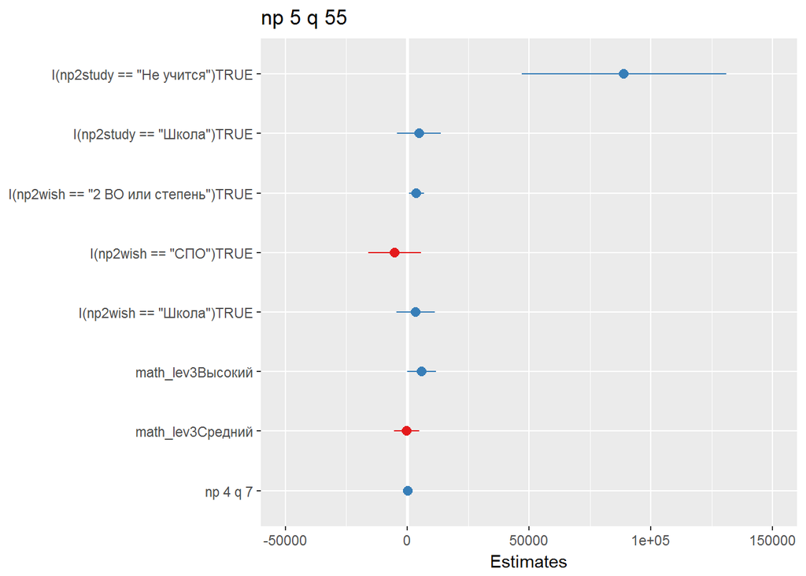

```r
plot_model(reg_salary, ci.lvl = 0.9)
```

С боле высокими зарплатными ожиданиями положительно связан балл ЕГЭ по математике и ожидаемый уровень образования - 2 высших или ученая степень. Число тех, кто не обучался во второй волне, крайне мало (2 человека), так что этим коэффициентом можем пренебречь.Однако уровень математической грамотности оказался не связан с ожиданиями - возможно, из-за включения в модель балла ЕГЭ. Проверим модель без ЕГЭ.

```r
reg_salary2 <- lm(data = data_salary, np5_q55 ~ math_lev3 +  I(np2study == "Не учится") + I(np2study == "Школа") +  I(np2wish == "Школа") + I(np2wish == "СПО") + I(np2wish == "2 ВО или степень"), na.action = na.omit)
summary(reg_salary2)
```

```
##
## Call:
## lm(formula = np5_q55 ~ math_lev3 + I(np2study == "Не учится") +
##     I(np2study == "Школа") + I(np2wish == "Школа") + I(np2wish ==
##     "СПО") + I(np2wish == "2 ВО или степень"), data = data_salary,
##     na.action = na.omit)
##
## Residuals:
##    Min     1Q Median     3Q    Max
## -40302 -15255  -5255   9745 129745
##
## Coefficients:
##                                      Estimate Std. Error t value Pr(>|t|)
## (Intercept)                           34424.1     2909.7  11.831  < 2e-16
## math_lev3Средний                        595.9     2539.4   0.235  0.81451
## math_lev3Высокий                       7841.7     2909.4   2.695  0.00711
## I(np2study == "Не учится")TRUE        53857.2    17584.5   3.063  0.00223
## I(np2study == "Школа")TRUE             5235.1     2149.9   2.435  0.01501
## I(np2wish == "Школа")TRUE              2388.9     4577.8   0.522  0.60185
## I(np2wish == "СПО")TRUE               -2964.7     5059.3  -0.586  0.55796
## I(np2wish == "2 ВО или степень")TRUE   2801.1     1674.7   1.673  0.09462
##
## (Intercept)                          ***
## math_lev3Средний
## math_lev3Высокий                     **
## I(np2study == "Не учится")TRUE       **
## I(np2study == "Школа")TRUE           *
## I(np2wish == "Школа")TRUE
## I(np2wish == "СПО")TRUE
## I(np2wish == "2 ВО или степень")TRUE .
## ---
## Signif. codes:  0 '***' 0.001 '**' 0.01 '*' 0.05 '.' 0.1 ' ' 1
##
## Residual standard error: 24670 on 1500 degrees of freedom
##   (138 observations deleted due to missingness)
## Multiple R-squared:  0.02718,    Adjusted R-squared:  0.02264
## F-statistic: 5.987 on 7 and 1500 DF,  p-value: 6.781e-07
```

Действительно, при исключении балла ЕГЭ из модели уровень математичекой грамотности оказался положительно связан с ожидаемой заработной платой. Кроме того, значимо положительно связано обучение в школе во второй волне по сравнению с обучением в СПО. Однако пропала значимость у коэффициента для высоких ожиданий для максимального уровня образования.

Сравним модель с ЕГЭ и без ЕГЭ

```r
#waldtest.default(reg_salary, reg_salary2)
```

Не работает и пишет, что models were not all fitted to the same size of dataset - абсолютно не знаю, что с этим делать(

# 4 Классификация

```r
set.seed(101)
train_rows <- createDataPartition(data_fct$np5plans,  p = 0.6, list = FALSE)
sample_train <- data_salary[train_rows, ]
sample_test <- data_salary[-train_rows, ]
```

```r
choice_model <- train(data = sample_train, np5plans ~ I(np2study == "Не учится") + I(np2study == "Школа") +  I(np2wish == "Школа") + I(np2wish == "СПО") + I(np2wish == "2 ВО или степень"), family = binomial(link = 'logit'), method = 'glm', na.action = na.omit)
summary(choice_model)
```

```
##
## Call:
## NULL
##
## Deviance Residuals:
##     Min       1Q   Median       3Q      Max
## -1.7648  -1.4473   0.9296   0.9296   1.2272
##
## Coefficients:
##                                        Estimate Std. Error z value
## (Intercept)                              0.2556     0.2855   0.895
## `I(np2study == "Не учится")TRUE`       -13.8216   535.4112  -0.026
## `I(np2study == "Школа")TRUE`             0.3597     0.2922   1.231
## `I(np2wish == "Школа")TRUE`             -0.3719     0.4829  -0.770
## `I(np2wish == "СПО")TRUE`                0.6411     0.6840   0.937
## `I(np2wish == "2 ВО или степень")TRUE`   0.7055     0.2251   3.134
##                                        Pr(>|z|)
## (Intercept)                             0.37065
## `I(np2study == "Не учится")TRUE`        0.97940
## `I(np2study == "Школа")TRUE`            0.21831
## `I(np2wish == "Школа")TRUE`             0.44117
## `I(np2wish == "СПО")TRUE`               0.34865
## `I(np2wish == "2 ВО или степень")TRUE`  0.00173 **
## ---
## Signif. codes:  0 '***' 0.001 '**' 0.01 '*' 0.05 '.' 0.1 ' ' 1
##
## (Dispersion parameter for binomial family taken to be 1)
##
##     Null deviance: 927.45  on 729  degrees of freedom
## Residual deviance: 912.10  on 724  degrees of freedom
## AIC: 924.1
##
## Number of Fisher Scoring iterations: 12
```

```r
choice_pred <- predict(choice_model, newdata = sample_train, na.action = na.omit)
head(choice_pred)
```

```
## [1] 1 1 1 1 1 1
## Levels: 0 1
```

```r
choice_prob <- predict(choice_model, newdata = sample_train, type = "prob" , na.action = na.omit)
head(choice_prob)
```

```
##            0         1
## 26 0.3508611 0.6491389
## 27 0.2106983 0.7893017
## 29 0.4364541 0.5635459
## 41 0.3508611 0.6491389
## 50 0.3508611 0.6491389
## 53 0.3508611 0.6491389
```

```r
#confusionMatrix(data = choice_pred, reference = sample_test$np5plans, na.action = na.omit)
```

Про матрицу же пишет, что all arguments must have the same length - не понимаю его, ведь я сделала одну и ту же модель ((

Нарисуем ROC-кривую

```r
# choice_model_set <- data.frame(H = choice_prob$H, L = choice_prob$L,pred = choice_pred, obs = sample_test$np5plans)

#ggplot(choice_model_set, aes(d = obs, m = L)) +
#  geom_roc(n.cuts = 0)
```

То же - пишет, что аргументы подразумевают разное количество строк.

Итого: от некоторых ошибок избавиться так и не удалось. Нужен отдельный курс по работе с пропущенными значениями в R - куда их деть, чтобы не мешались.